# O centro presidencial no Brasil

Igor Brito

Setembro, 2022

# Resumo

Este trabalho objetiva analisar o efeito da quantidade de partidos no gabinete no tamanho do centro presidencial no Brasil. A expansão do centro presidencial é tida como uma estratégia do presidente para lidar com o risco de agência advindo da distribuição de ministérios aos partidos da coalizão. Os dados cobrem o período de 1985 a 2016 e a estratégia de análise empregada foi a regressão linear simples. Os resultados evidenciaram uma associação positiva e estatisticamente significante entre essas variáveis. Contudo, esses resultados devem ser encarados como provisórios, considerando as limitações de quantidade de observações utilizadas na análise e de emprego de uma técnica de análise modesta (regressão linear simples) que não trata algumas características dos dados utilizados (como a dependência das observações).

# 1 Introdução

O objetivo deste trabalho é analisar o efeito da quantidade de partidos no gabinete no tamanho do centro presidencial no Brasil entre 1985 e 2016. O centro presidencial pode ser entendido como o núcleo que apoia diretamente o trabalho do chefe de governo e busca reforçar sua autoridade e liderança, bem como sua autonomia e recursos políticos, articulando dispositivos de centralização de poderes dentro do Executivo (Lanzaro 2018).

O principal pressuposto assumido nesta pesquisa é que o presidente enfrenta um trade-off relacionado à expansão do centro presidencial. Por um lado, uma maior quantidade de órgãos de apoio direto promove um reforço da liderança do presidente, tanto em termos de um maior controle da ação dos ministérios quanto por meio da centralização da produção de políticas na Presidência. Por outro, o crescimento do centro presidencial aumenta o custo de gestão interna deste e limita a autonomia dos ministros. Especificamente, em casos de governos de coalizão, essa redução da autonomia dos ministros dos partidos da coalizão representa uma menor recompensa em fazer parte do governo, o que pode provocar a saída desses partidos da coalizão. Diante disso, o presidente tende a usar a estratégia de expansão do centro presidencial de forma cautelosa e em momentos de maior ameaça a sua liderança.

A principal explicação para a variação no tamanho do centro presidencial na América Latina está baseada na relação entre o presidente e seus ministros em governos de coalizão, situação em que, potencialmente, há grande divergência de preferência entre esses atores políticos. Para compreender essa explicação é salutar compreender a lógica de formação de governo na região, bem como os mecanismos empregados pelo presidente para lidar com as adversidades produzidas por essa lógica.

Desde o artigo seminal de Juan Linz (1990) alertando do perigo do presidencialismo, passando pela difícil combinação do presidencialismo com o multipartidarismo (Mainwaring e Shugart 1997) até as diversas ferramentas utilizadas pelos presidentes visando criar uma cooperação relativamente estável com o Poder Legislativo (Chaisty, Cheeseman, e Power 2014), uma série de trabalhos vem explorando as diversas facetas do que se convencionou chamar de presidencialismo de coalizão.

Uma das ferramentas essenciais para que o presidente possa criar uma relação de cooperação estável com o Congresso é a distribuição de cargos dentro do Poder Executivo para membros de partidos da coalizão (Amorim Neto 2006; Martínez-Gallardo 2014). Se por um lado essa estratégia visa garantir uma base parlamentar de apoio ao governo, por outro, ela diminui o controle presidencial sobre os órgãos executivos chefiados pelos parceiros da coalizão. Como bem coloca Batista (2013, 450) “[c]omo representante do partido, o ministro tem uma ideologia, preferências políticas, projetos eleitorais e seu partido tem uma agenda política própria e isto pode afetar diretamente as decisões tomadas pelo governo”.

Portanto, há de se esperar que quanto maior a quantidade de partidos no gabinete, maior será o risco de agência e, assim, maior será o incentivo para que o presidente expanda o centro presidencial. Logo, este trabalho irá testar a seguinte hipótese:

*H1: O centro presidencial expandirá quanto maior for a quantidade de partidos no gabinete.*[^1]

# 2 Método

Os dados são referentes ao Brasil, caso típico de presidencialismo de coalizão, entre o ano de 1985 e 2016. Os dados sobre o tamanho do centro presidencial foram coletados nos dados de replicação de Inácio e Llanos (2015) para o período de 1985 a 2002. Para o período de 2003 a 2016 foi realizada a coleta dos dados diretamente de fontes primárias (normas de organização do Poder Executivo do Brasil). A quantidade de partidos no gabinete foi obtida no texto de Amorim Neto (2019). Os dados possuem granularidade anual, sendo 32 observações ao total.

O modelo escolhido para promover o teste da hipótese de pesquisa (H1) foi a regressão linear, pois tanto a variável dependente (tamanho do centro presidencial) quanto a variável independente (quantidade de partidos no gabinete) são contínuas. Assim, o modelo pode ser escrito da seguinte forma:

$tam\_cp = \beta_0 + \beta_1*qtd\_part$

Sendo H1 representada por $\beta_1 \neq 0$.

# 3 Análise

## 3.1 Análise exploratória dos dados

Inicialmente, é importante fazer uma análise exploratória dos dados para facilitar a compreensão destes antes de se proceder com o teste de hipótese. Assim, seguindo as diretrizes de análise exploratória sugeridas por Ismay e Kim (2019), foi feita a visualização dos dados brutos, o cálculo de estatísticas descritivas e a visualização gráfica dos dados.

Como a base de dados contém 32 observações, procedeu-se com a visualização de uma amostra aleatória de 5 observações dos dados brutos. Essa amostra pode ser vista na tabela abaixo.

| ano | tam_cp | gabinete | qtd_part | partidos |
| --- | --- | --- | --- | --- |
| 2001 | 12 | Cardoso II-2 | 5 | PSDB, PFL, PMDB, PPB, PPS |
| 2003 | 21 | Lula da Silva I-1 | 8 | PT, PTB, PL, PSB, PPS, PDT, PCdoB, PV |
| 2006 | 21 | Lula da Silva I-3 | 9 | PT, PMDB, PTB, PL, PSB, PPS, PCdoB, PV, PP |
| 2012 | 23 | Rousseff I-2 | 6 | PT, PMDB, PP, PR, PSB, PCdoB |
| 2013 | 23 | Rousseff I-3 | 8 | PT, PMDB, PP, PR, PSB, PCdoB, PRB, PDT |

O próximo passo então é o cômputo das estatísticas descritivas das variáveis que utilizadas na análise, quais sejam: $tam\_cp$ e $qtd\_part$.

```
##      tam_cp         qtd_part
##  Min.   : 6.00   Min.   : 2.000
##  1st Qu.:10.75   1st Qu.: 3.750
##  Median :14.50   Median : 6.000
##  Mean   :15.41   Mean   : 5.844
##  3rd Qu.:21.00   3rd Qu.: 8.000
##  Max.   :24.00   Max.   :10.000
```

Como pode ser visto acima, o tamanho do centro presidencial brasileiro ($tam\_cp$) variou entre 6 e 24 órgãos ligados diretamente à Presidência da República entre 1985 e 2016, sendo a média 15,41. Para esse mesmo período, a quantidade de partidos teve seu mínimo de 2 e o máximo de 10, sendo a média 6.

Ainda no sentido de promover uma melhor compreensão dos dados, foi elaborado um gráfico de dispersão abaixo. Além dos pontos correspondentes a cada observação dos dados, foi incluído no gráfico o modelo linear que melhor se ajusta aos pontos.

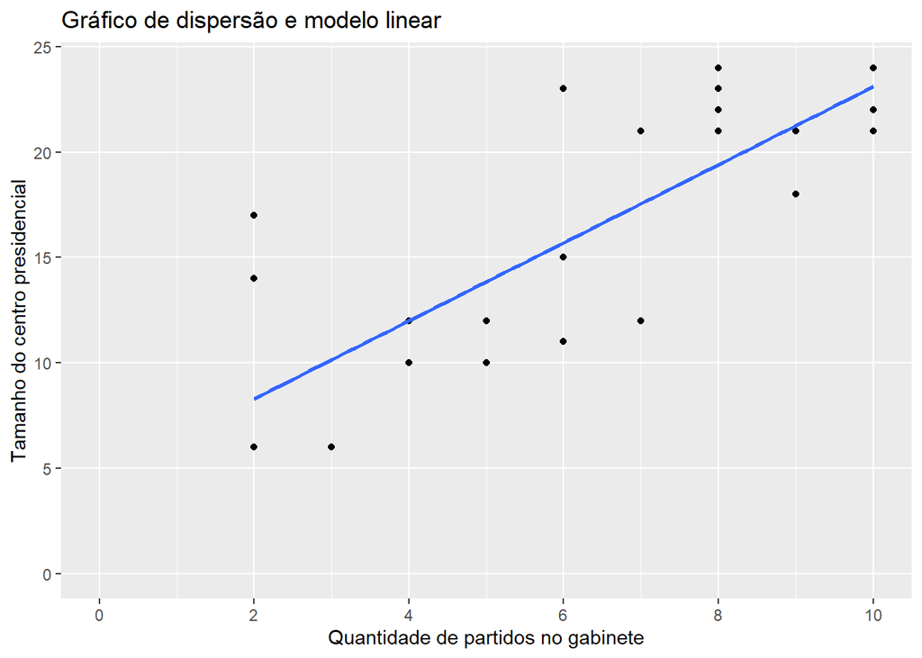

## 3.2 Regressão linear

Feita essa análise exploratória dos dados, parte-se então para o teste de hipótese. Nesse sentido, os resultados do modelo de regressão lienar simples podem ser visto na tabela abaixo.

| term | estimate | std_error | statistic | p_value | lower_ci | upper_ci |
| --- | --- | --- | --- | --- | --- | --- |
| intercept | 4.589 | 1.621 | 2.831 | 0.008 | 1.279 | 7.900 |
| qtd_part | 1.851 | 0.253 | 7.325 | 0.000 | 1.335 | 2.367 |

O coeficiente estimado de $qtd\_part$ é 1.9 aproximadamente. Ou seja, para cada acréscimo de um partido no gabinete, existe um acréscimo associado, em média, de 1.9 órgãos no centro presidencial. O intervalo de confiança de 95% para esse parâmetro é [1.335, 2.367]. O p-valor é baixíssimo (< 0.000), portanto, esse resultado é significante estatisticamente aos níveis convencionais de confiança (10%, 5%, 1% e 0.1%).

Contudo, a tabela de regressão acima apresenta os intervalos de confiança e o teste de hipótese utilizando os modelos teóricos. Considerando que a distribuição dos dados não é exatamente normal e que a quantidade de observações é relativamente pequena, optou-se por promover também um teste de hipótese que não tomasse como pressuposto a normalidade dos dados. Portanto, foi realizado um teste com a técnica de reamostragem simulada (bootstrap) com intervalos de confiança feitos pelo método do percentil.

O p-valor do teste de hipósetes deu aproximadamente 0, conforme pode ser visto abaixo. Esse resultado corrobora a significância estatística do resultado da tabela de regressão.

```
## # A tibble: 1 × 1
##   p_value
##     <dbl>
## 1       0
```

O intervalo de confiança de 95% construído por meio da reamostragem (bootstrap) com o método do percentil é:

```
## # A tibble: 1 × 2
##   lower_ci upper_ci
##      <dbl>    <dbl>
## 1     1.38     2.34
```

Esse intervalo de confiança também se aproxima bastante do resultado da tabela de regressão.

## 3.3 Análise dos resíduos

Segundo Ismay e Kim (2019), as seguintes condições precisam ser satisfeitas para que o resultados da regressão sejam válidos:

1. Relação linear entre as variáveis;
2. Independência dos resíduos;
3. Normalidade dos resíduos;
4. Igualdade de variância dos resíduos.

Para o presente caso, a primeira condição (linearidade) é relativamente satisfeita, como pode ser visto no gráfico de dispersão dos dados brutos da seção 3.1.

A condição de independência dos resíduos depende da etapa amostral, especificamente, se as asmostras são independentes entre si. No presente caso, todas as amostras são do mesmo país (Brasil) e de anos seguidos (1985-2016). Desta forma, não é possível afirmar que a condição de independência é satisfeita. Portanto, os resultados aqui apresentados devem ser interpretados de forma preliminar e com cautela. O avanço dessa agenda de pesquisa pode incorporar métodos estatísticos mais avançados para lidar com essa limitação.

A condição de normalidade dos resíduos pode ser verificada, grosso modo, por meio da análise visual destes. O gráfico abaixo serve a esse propósito.

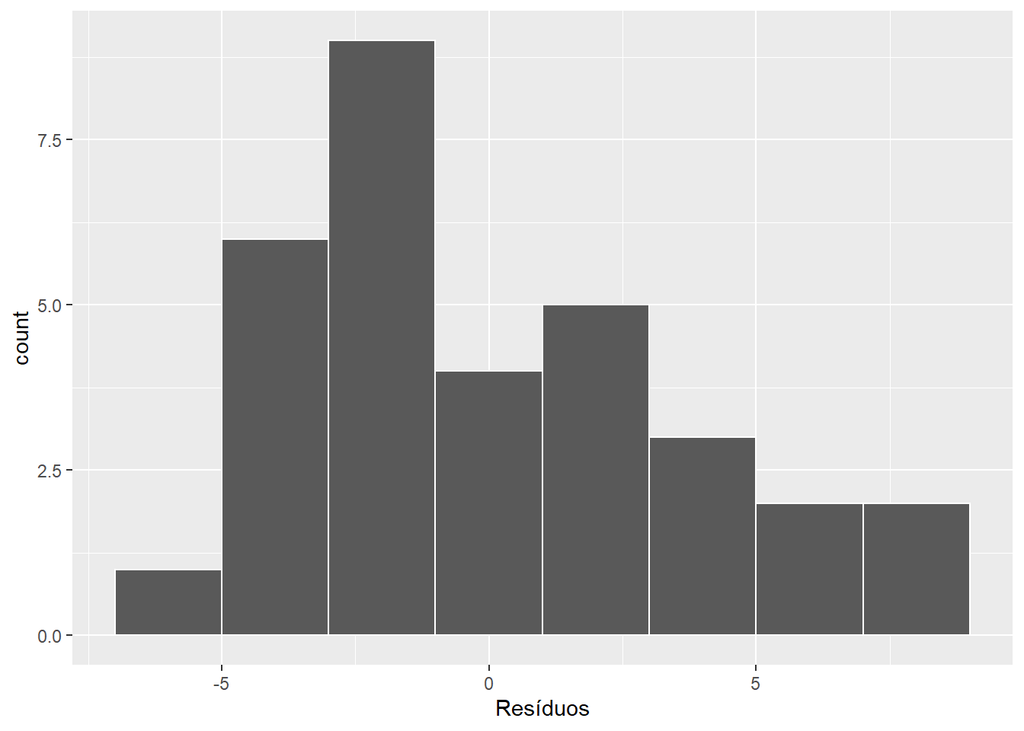

O gráfico acima mostra que a distribuição dos resíduos lembra muito vagamente uma distribuição normal. Uma questão que merece destaque aqui é a baixa quantidade de observações. Talvez uma extensão da análise com um número maior de observações poderia gerar uma distribuição dos resíduos que se aproximasse mais de uma curva nornal.

Por fim, é importante verificar se a condição de igualdade de variância dos resíduos é atendida. Para tanto, foi feita um análise visual desses resíduos visando verificar se as variâncias dos resíduos dependem ou não da variável independente ($qtd\_part$).

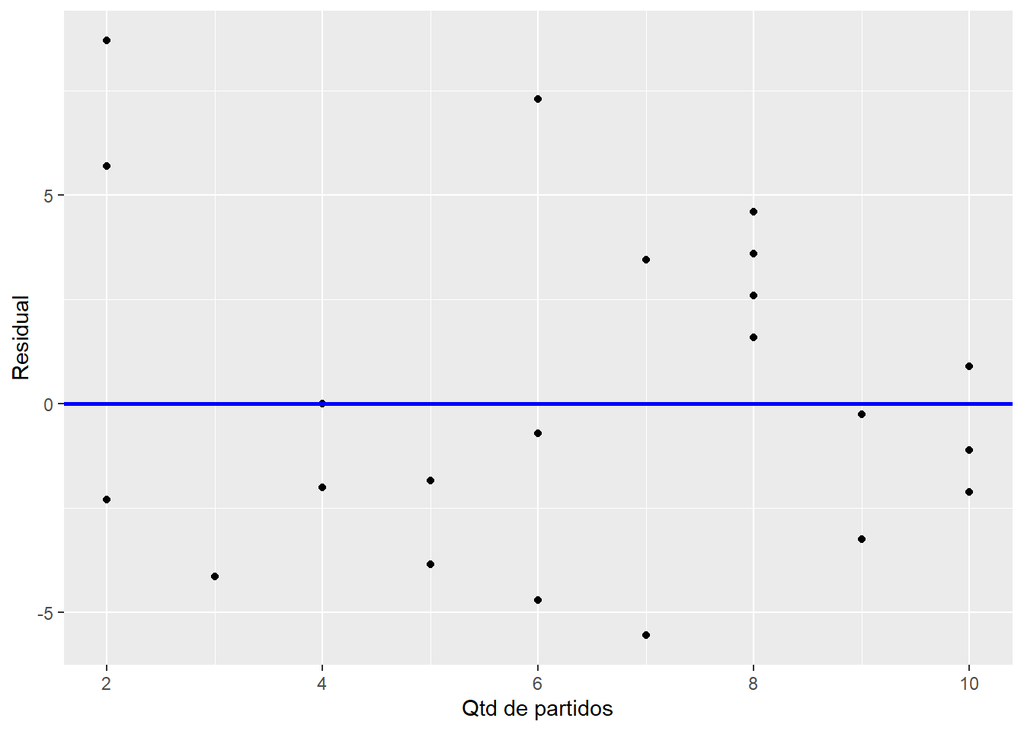

Como pode ser visto no gráfico acima, a variância dos resíduos não parece ter nenhuma relação clara com a quantidade de partidos no gabinete. Portanto, é possível afirmar que essa condição foi satisfeita.

# 4 Conclusões

O presente relatório objetivou testar a hipótese de que uma maior quantidade de partidos no gabinete leva ao aumento do tamanho do centro presidencial. Com base na análise feita aqui, foi possível verificar preliminarmente que há uma associação positiva e estatisticamente significante entre essas variáveis.

Contudo, os resultados aqui apresentados devem ser interpretados com bastante cautela. A quantidade de observações utilizadas nesta análise foi relativamente pequena ($n=32$) e elas não são independentes entre si, pois referem-se a um mesmo país (Brasil) ao longo de alguns anos (1985-2016). Portanto, esses resultados devem ser tidos como provisórios.

Uma agenda de pesquisa futura pode expandir a quantidade de casos analisados, aumentando a quantidade de observações, e aplicar outros modelos estatísticos mais avançados para lidar com as limitações deste trabalho.

# Referências

Amorim Neto, Octavio. 2006. «The presidential calculus: Executive policy making and cabinet formation in the Americas». *Comparative Political Studies* 39 (4): 415–40. https://doi.org/10.1177/0010414005282381.

———. 2019. «Cabinets and coalitional presidentialism». Em *Routledge Handbook of Brazilian Politics*, editado por Barry Ames, 293–312. New York: Routledge.

Batista, Mariana. 2013. «O Poder no Executivo: uma análise do papel da Presidência e dos Ministérios no presidencialismo de coalizão brasileiro (1995-2010)». *Opinião Pública* 19 (2): 449–73.

Chaisty, Paul, Nic Cheeseman, e Timothy Power. 2014. «Rethinking the ’presidentialism debate’: Conceptualizing coalitional politics in cross-regional perspective». *Democratization* 21 (1): 72–94. https://doi.org/10.1080/13510347.2012.710604.

Inácio, Magna, e Mariana Llanos. 2015. «The Institutional Presidency from a Comparative Perspective: Argentina and Brazil since the 1980s». *Brazilian Political Science Review* 9 (1): 39–64. https://doi.org/10.1590/1981-38212014000200002.

———. 2016. «The Institutional Presidency in Latin America: A Comparative Analysis». *Presidential Studies Quarterly* 46 (3): 531–49. https://doi.org/10.1111/psq.12297.

Ismay, Chester, e Albert Y. Kim. 2019. *Statistical inference via data science: A ModernDive into R and the tidyverse.* London: CRC Press. https://moderndive.com/.

Lanzaro, Jorge. 2018. «Introducción». Em *Centro Presidencial: presidencias y centros de gobierno en América Latina, Estados Unidos y Europa*, editado por Jorge Lanzaro, 13–38. Madrid: Tecnos.

Linz, Juan. 1990. «The Perils of Presidentialism». *Journal of Democracy* 1 (1): 51–69. https://doi.org/10.1353/jod.2005.0026.

Mainwaring, Scott, e Matthew S. Shugart. 1997. «Juan Linz, Presidentialism, and Democracy: A Critical Appraisal». *Comparative Politics* 29 (4): 449–71. https://doi.org/10.4324/9780203440803-7.

Martínez-Gallardo, Cecilia. 2014. «Designing Cabinets: Presidential Politics and Ministerial Instability». *Journal of Politics in Latin America* 6 (2): 3–38. https://doi.org/10.1177/1866802x1400600201.

[^1]: O teste dessa hipótese tem finalidade didática para apresentação do trabalho final da disciplina de Métodos Quantitativos Aplicados à Ciência Política - 2022/1. Inácio e Llanos (2015) e Inácio e Llanos (2016) já testaram essa hipótese de forma comparada e com variáveis de controle. Aqui eu utilizo parte dos dados dessas autoras, mas também complemento com dados do Brasil dos últimos anos.